# Tree Data Import

Guangchuang Yu (guangchuangyu@gmail.com) and Tommy Tsan-Yuk Lam (ttylam@hku.hk) School of Public Health, The University of Hong Kong

2015-12-31

# Contents

The *ggtree* package should not be viewed solely as a standalone software. While it is useful for viewing, annotating and manipulating phylogenetic trees, it is also an infrastructure that enables evolutionary evidences that inferred by commonly used software packages in the field to be used in `R`. For instance, *dN/dS* values or ancestral sequences inferred by [CODEML](http://abacus.gene.ucl.ac.uk/software/paml.html)<sup>1</sup>, *clade support values (posterior)* inferred by [BEAST](http://beast2.org/)<sup>2</sup> and short read placement by [EPA](http://sco.h-its.org/exelixis/web/software/epa/index.html)<sup>3</sup> and [pplacer](http://matsen.fhcrc.org/pplacer/)<sup>4</sup>. These evolutionary evidences are not only used in annotating phylogenetic tree in *ggtree* but can also be further analyzed in `R`.

# 1 Supported File Formats

Most of the tree viewer software (including `R` packages) focus on `Newick` and `Nexus` file format, while there are file formats from different evolution analysis software that contain supporting evidences within the file that are ready for annotating a phylogenetic tree. The *ggtree* package define several parser functions and `S4` classes to store statistical evidences inferred by commonly used software packages. It supports several file format, including:

- Newick (via `ape`)
- Nexus (via `ape`)
- New Hampshire eXtended format (NHX)
- Jplace

and software output from:

- [BEAST](http://beast2.org/)<sup>2</sup>
- [EPA](http://sco.h-its.org/exelixis/web/software/epa/index.html)<sup>3</sup>
- [HYPHY](http://hyphy.org/w/index.php/Main_Page)<sup>5</sup>
- [PAML](http://abacus.gene.ucl.ac.uk/software/paml.html)<sup>1</sup>
- [PHYLDOG](http://pbil.univ-lyon1.fr/software/phyldog/)<sup>6</sup>
- [pplacer](http://matsen.fhcrc.org/pplacer/)<sup>4</sup>
- [r8s](http://loco.biosci.arizona.edu/r8s/)<sup>7</sup>
- [RAxML](http://sco.h-its.org/exelixis/web/software/raxml/)<sup>8</sup>
- [RevBayes](http://revbayes.github.io/intro.html)<sup>9</sup>

# 2 Parser functions

The *ggtree* package implement several parser functions, including:

- `read.beast` for parsing output of [BEASE](http://beast2.org/)
- `read.codeml` for parsing output of [CODEML](http://abacus.gene.ucl.ac.uk/software/paml.html) (`rst` and `mlc` files)
- `read.codeml_mlc` for parsing `mlc` file (output of `CODEML`)
- `read.hyphy` for parsing output of [HYPHY](http://hyphy.org/w/index.php/Main_Page)
- `read.jplace` for parsing `jplace` file including output from [EPA](http://sco.h-its.org/exelixis/web/software/epa/index.html) and [pplacer](http://matsen.fhcrc.org/pplacer/)
- `read.nhx` for parsing `NHX` file including output from [PHYLODOG](http://pbil.univ-lyon1.fr/software/phyldog/) and RevBayes](http://revbayes.github.io/intro.html)
- `read.paml_rst` for parsing `rst` file (output of `BASEML` and `CODEML`)
- `read.r8s` for parsing output of r8s
- `read.raxml` for parsing output of [RAxML](http://sco.h-its.org/exelixis/web/software/raxml/)

# 3 S4 classes

Correspondingly, *ggtree* define several `S4` classes to store evolutionary evidences inferred by these software packages, including:

- *`apeBootstrap`* for bootstrap analysis of `ape::boot.phylo()`<sup>10</sup>, output of `apeBoot()` defined in `ggtree`
- *`beast`* for storing output of `read.beast()`
- *`codeml`* for storing output of `read.codeml()`
- *`codeml_mlc`* for storing output of `read.codeml_mlc()`
- *`hyphy`* for storing output of `read.hyphy()`
- *`jplace`* for storing output of `read.jplace()`
- *`nhx`* for storing output of `read.nhx()`
- *`paml_rst`* for *`rst`* file obtained by [PAML], including *`BASEML`* and *`CODEML`*.
- *`phangorn`* for storing ancestral sequences inferred by `R` package `phangorn`<sup>11</sup>, output of `phyPML()` defined in `ggtree`
- *`r8s`* for storing output of `read.r8s()`
- *`raxml`* for storing output of `read.raxml()`

The *`jplace`* class is also designed to store user specific annotation data, and serves as a standard format for tree annotation within the *ggtree* package.

Here is an overview of these `S4` classes:

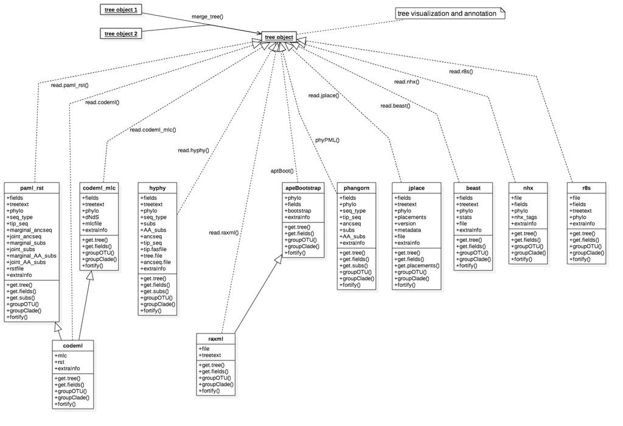

In addition, `ggtree` also supports *`phylo`* (defined by *[ape](http://cran.fhcrc.org/web/packages/ape/index.html)*<sup>10</sup>) and *`phylo4`* (defined by *[phylobase](http://cran.fhcrc.org/web/packages/phylobase/index.html)*).

In `ggtree`, tree objects can be merged and evidences inferred from different phylogenetic analyses can be combined or compared and visualized.

Viewing a phylogenetic tree in `ggtree` is easy by using the command `ggtree(tree_object)` and annotating a phylogenetic tree is simple by adding graphic layers using the grammar of graphics.

For each class, we defined *`get.fields`* method to get the annotation features that available in the object that can be used to annotate a phylogenetic tree directly in `ggtree`. A *`get.tree`* method can be used to convert tree object to `phylo` object that are widely supported by other `R` packages.

The *`groupOTU`* method is used for clustering related OTUs (from tips to their most recent common ancestor). Related OTUs are not necessarily within a clade, they can be distantly related. *`groupOTU`* works fine for monophyletic (clade), polyphyletic and paraphyletic, while *`groupClade`* only works for clade (monophyletic). These methods are useful for clustering related OTUs or clades.

The *`fortify`* method is used to convert tree object to a `data.frame` which is familiar by `R` users and easy to manipulate. The output `data.frame` contains tree information and all evolutionary evidences (if available, e.g. *dN/dS* in `codeml` object).

# 4 Getting Tree Data into R

## 4.1 Parsing BEAST output

```r
file <- system.file("extdata/BEAST", "beast_mcc.tree", package="ggtree")
beast <- read.beast(file)
beast
```

```
## 'beast' S4 object that stored information of
##   '/private/var/folders/32/47tc79h16kjbv_bdb8tncjnh0000gn/T/RtmpBrT5pz/Rinst3ed3105f72df/ggtree/extdata/BEAST/beast_mcc.tree'.
##
## ...@ tree:
## Phylogenetic tree with 15 tips and 14 internal nodes.
##
## Tip labels:
##  A_1995, B_1996, C_1995, D_1987, E_1996, F_1997, ...
##
## Rooted; includes branch lengths.
##
## with the following features available:
##   'height',  'height_0.95_HPD',  'height_median',    'height_range', 'length',
##   'length_0.95_HPD', 'length_median',    'length_range', 'posterior',    'rate',
##   'rate_0.95_HPD',   'rate_median',  'rate_range'.
```

Since *`%`* is not a valid character in *`names`*, all the feature names that contain *`x%`* will convert to *`0.x`*. For example, *`length_95%_HPD`* will be changed to *`length_0.95_HPD`*.

The *`get.fields`* method return all available features that can be used for annotation.

```r
get.fields(beast)
```

```
##  [1] "height"          "height_0.95_HPD" "height_median"
##  [4] "height_range"    "length"          "length_0.95_HPD"
##  [7] "length_median"   "length_range"    "posterior"
## [10] "rate"            "rate_0.95_HPD"   "rate_median"
## [13] "rate_range"
```

Users can use `ggtree(beast)` to visualize the tree and add layer to annotate it.

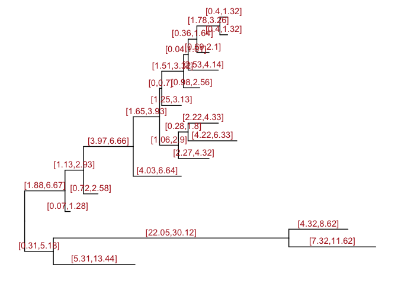

```r
ggtree(beast, ndigits=2, branch.length = 'none') + geom_text(aes(x=branch, label=length_0.95_HPD), vjust=-.5, color='firebrick')
```

With `ggtree`, evolutionary evidences inferred by commonly used software packages (`BEAST` in this example) can be easily obtained in a tidy `data.frame` by `fortify` method.

```r
beast_data <- fortify(beast)
head(beast_data)
```

```
##   node parent branch.length        x  y  label isTip    branch angle
## 1    1     26     1.3203366 19.92609 13 A_1995  TRUE 19.265920  -222
## 2    2     25     3.2619545 20.92609 12 B_1996  TRUE 19.295111  -198
## 3    3     28     3.3119924 19.92609  7 C_1995  TRUE 18.270092   -66
## 4    4     17     8.8216633 11.92609  1 D_1987  TRUE  7.515257    66
## 5    5     29     3.2710481 20.92609  9 E_1996  TRUE 19.290565  -126
## 6    6     27     0.8311578 21.92609 14 F_1997  TRUE 21.510510  -246
##   height height_0.95_HPD height_median height_range    length
## 1     18         [18,18]            18      [18,18] 1.3441569
## 2     17         [17,17]            17      [17,17] 3.3017477
## 3     18         [18,18]            18      [18,18] 3.3286573
## 4     26         [26,26]            26      [26,26] 9.1413106
## 5     17         [17,17]            17      [17,17] 3.2862156
## 6     16         [16,16]            16      [16,16] 0.8488314
##                        length_0.95_HPD length_median
```

[output cut: 27 more lines]

## 4.2 Parsing PAML output

### 4.2.1 *`rst`* file

The *`read.paml_rst`* function can parse `rst` file from `BASEML` and `CODEML`. The only difference is the space in the sequences. For `BASEML`, each ten bases are separated by one space, while for `CODEML`, each three bases (triplet) are separated by one space.

```r
brstfile <- system.file("extdata/PAML_Baseml", "rst", package="ggtree")
brst <- read.paml_rst(brstfile)
brst
```

```
## 'paml_rst' S4 object that stored information of
##   '/private/var/folders/32/47tc79h16kjbv_bdb8tncjnh0000gn/T/RtmpBrT5pz/Rinst3ed3105f72df/ggtree/extdata/PAML_Baseml/rst'.
##
## ...@ tree:
## Phylogenetic tree with 15 tips and 13 internal nodes.
##
## Tip labels:
##  A, B, C, D, E, F, ...
## Node labels:
##  16, 17, 18, 19, 20, 21, ...
##
## Unrooted; includes branch lengths.
##
## with the following features available:
##   'marginal_subs',   'joint_subs',   'marginal_AA_subs', 'joint_AA_subs'.
```

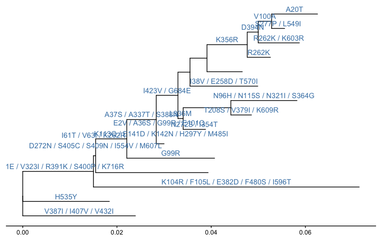

```r
p <- ggtree(brst) +
    geom_text(aes(x=branch, label=marginal_AA_subs), vjust=-.5, color='steelblue') +
    theme_tree2()
print(p)
```

Similarly, we can parse the `rst` file from `CODEML` and visualize the tree with amino acid substitution.

```r
crstfile <- system.file("extdata/PAML_Codeml", "rst", package="ggtree")
crst <- read.paml_rst(crstfile)
crst
```

```
## 'paml_rst' S4 object that stored information of
##   '/private/var/folders/32/47tc79h16kjbv_bdb8tncjnh0000gn/T/RtmpBrT5pz/Rinst3ed3105f72df/ggtree/extdata/PAML_Codeml/rst'.
##
## ...@ tree:
## Phylogenetic tree with 15 tips and 13 internal nodes.
##
## Tip labels:
##  A, B, C, D, E, F, ...
## Node labels:
##  16, 17, 18, 19, 20, 21, ...
##
## Unrooted; includes branch lengths.
##
## with the following features available:
##   'marginal_subs',   'joint_subs',   'marginal_AA_subs', 'joint_AA_subs'.
```

In `ggtree`, we define the `update` operator, `%<%`, that can update a tree view (applying the same pattern of visualization and annotation) with another tree object.

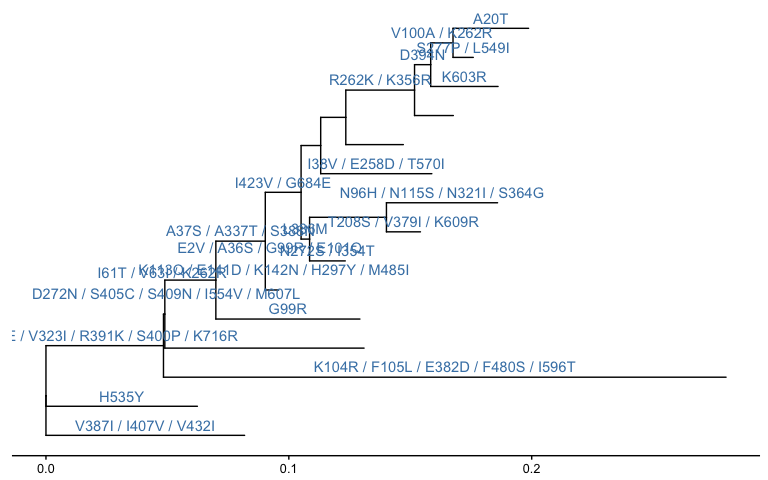

```r
p %<% crst
```

We can find that these two figures have different evolution distances and subsitutions inferred by `BASEML` and `CODEML` are slightly different.

### 4.2.2 CODEML

#### 4.2.2.1 mlc file

The `mlc` file output by `CODEML` contains *`dN/dS`* estimation.

```r
mlcfile <- system.file("extdata/PAML_Codeml", "mlc", package="ggtree")
mlc <- read.codeml_mlc(mlcfile)
mlc
```

```
## 'codeml_mlc' S4 object that stored information of
##   '/private/var/folders/32/47tc79h16kjbv_bdb8tncjnh0000gn/T/RtmpBrT5pz/Rinst3ed3105f72df/ggtree/extdata/PAML_Codeml/mlc'.
##
## ...@ tree:
## Phylogenetic tree with 15 tips and 13 internal nodes.
##
## Tip labels:
##  A, B, C, D, E, F, ...
## Node labels:
##  16, 17, 18, 19, 20, 21, ...
##
## Unrooted; includes branch lengths.
##
## with the following features available:
##   't',   'N',    'S',    'dN_vs_dS', 'dN',   'dS',   'N_x_dN',   'S_x_dS'.
```

Please aware that *`/`* and *`*`* are not valid characters in *`names`*, they were changed to *`_vs_`* and *`_x_`* respectively.

So *`dN_vs_dS`* is *`dN/dS`*, *`N_x_dN`* is *`N*dN`*, and *`S_x_dS`* is *`S*dS`*.

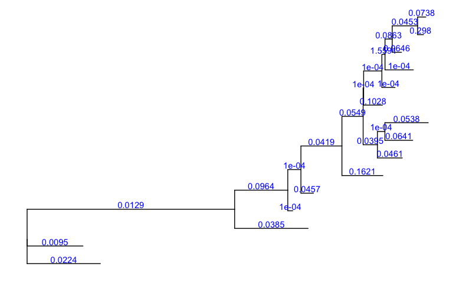

```r
ggtree(mlc) + geom_text(aes(x=branch, label=dN_vs_dS), color='blue', vjust=-.2)
```

The paramter *`branch.length`* can be one of available annotations:

```r
get.fields(mlc)
```

```
## [1] "t"        "N"        "S"        "dN_vs_dS" "dN"       "dS"
## [7] "N_x_dN"   "S_x_dS"
```

For example, if we set *`branch.length`* to *`dN_vs_dS`*, the tree view will be re-scaled based on $\omega$ (*`dN/dS`*).

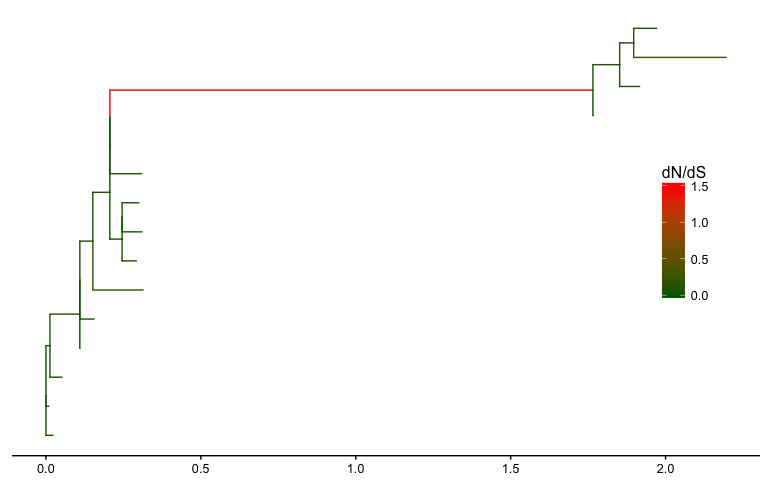

```r
ggtree(mlc, branch.length = "dN_vs_dS", aes(color=dN_vs_dS)) +
    scale_color_continuous(name='dN/dS', limits=c(0, 1.5),
                           oob=scales::squish, low="darkgreen", high="red")+
    theme_tree2(legend.position=c(.9, .5))
```

We can also plot the *`dN`* or *`dS`* tree and others.

#### 4.2.2.2 rst and mlc files

#### 4.2.2.3 *`CODEML`* output: rst and mlc files

We annotate the tree with information presented in *`rst`* and *`mlc`* file separately as demonstrated in previous sessions.

We can also use both of them which is highly recommended.

```r
ml <- read.codeml(crstfile, mlcfile)
ml
```

```
## 'codeml' S4 object that stored information of
##   '/private/var/folders/32/47tc79h16kjbv_bdb8tncjnh0000gn/T/RtmpBrT5pz/Rinst3ed3105f72df/ggtree/extdata/PAML_Codeml/rst' and
##  '/private/var/folders/32/47tc79h16kjbv_bdb8tncjnh0000gn/T/RtmpBrT5pz/Rinst3ed3105f72df/ggtree/extdata/PAML_Codeml/mlc'.
##
## ...@ tree:
## Phylogenetic tree with 15 tips and 13 internal nodes.
##
## Tip labels:
##  A, B, C, D, E, F, ...
## Node labels:
##  16, 17, 18, 19, 20, 21, ...
##
## Unrooted; includes branch lengths.
##
## with the following features available:
##   'marginal_subs',   'joint_subs',   'marginal_AA_subs', 'joint_AA_subs',
##   't',   'N',    'S',    'dN_vs_dS',
##   'dN',  'dS',   'N_x_dN',   'S_x_dS',
## .
```

```r
head(fortify(ml))
```

```
##    label node parent branch.length        x  y isTip    branch      angle
## 14     A    1     27      0.010340 0.417866 13  TRUE 0.4126960 -220.34483
## 15     B    2     26      0.031643 0.431097 12  TRUE 0.4152755 -195.51724
## 16     C    3     22      0.027730 0.418729  7  TRUE 0.4048640  -58.96552
## 17     D    4     17      0.082021 0.313649  3  TRUE 0.2726385   27.93103
## 18     E    5     23      0.031104 0.430431  8  TRUE 0.4148790  -96.20690
## 19     F    6     28      0.006649 0.442478 14  TRUE 0.4391535 -245.17241
##        t      N     S dN_vs_dS     dN     dS N_x_dN S_x_dS
## 14 0.010 1514.9 633.1   0.0646 0.0007 0.0101      1    6.4
## 15 0.032 1514.9 633.1   0.0001 0.0000 0.0358      0   22.7
## 16 0.028 1514.9 633.1   0.0461 0.0013 0.0282      2   17.9
## 17 0.082 1514.9 633.1   0.0385 0.0033 0.0849      5   53.8
## 18 0.031 1514.9 633.1   0.0641 0.0020 0.0305      3   19.3
## 19 0.007 1514.9 633.1   0.2980 0.0013 0.0044      2    2.8
##                                                                                                                                                                                                                                                                                                          …
```

[output cut: 27 more lines]

All the features in both files are available for annotation. For example, we can annotate *`dN/dS`* with the tree in *`rstfile`* and amino acid substitutions with the tree in *`mlcfile`*.

## 4.3 Parsing HYPHY output

```r
nwk <- system.file("extdata/HYPHY", "labelledtree.tree", package="ggtree")
ancseq <- system.file("extdata/HYPHY", "ancseq.nex", package="ggtree")
tipfas <- system.file("extdata", "pa.fas", package="ggtree")
hy <- read.hyphy(nwk, ancseq, tipfas)
hy
```

```
## 'hyphy' S4 object that stored information of
##   '/private/var/folders/32/47tc79h16kjbv_bdb8tncjnh0000gn/T/RtmpBrT5pz/Rinst3ed3105f72df/ggtree/extdata/HYPHY/labelledtree.tree',
##  '/private/var/folders/32/47tc79h16kjbv_bdb8tncjnh0000gn/T/RtmpBrT5pz/Rinst3ed3105f72df/ggtree/extdata/HYPHY/ancseq.nex' and
##  '/private/var/folders/32/47tc79h16kjbv_bdb8tncjnh0000gn/T/RtmpBrT5pz/Rinst3ed3105f72df/ggtree/extdata/pa.fas'.
##
## ...@ tree:
## Phylogenetic tree with 15 tips and 13 internal nodes.
##
## Tip labels:
##  K, N, D, L, J, G, ...
## Node labels:
##  Node1, Node2, Node3, Node4, Node5, Node12, ...
##
## Unrooted; includes branch lengths.
##
## with the following features available:
##   'subs',    'AA_subs'.
```

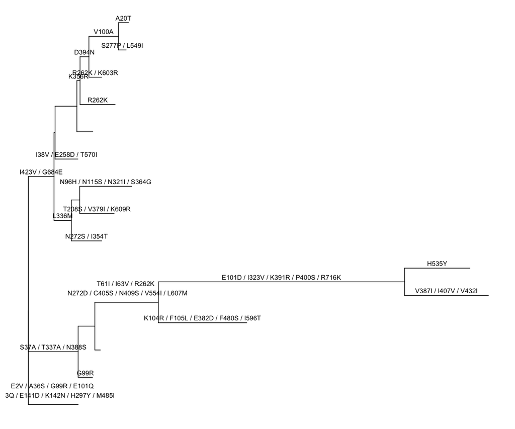

```r
ggtree(hy) + geom_text(aes(x=branch, label=AA_subs), vjust=-.5)
```

## 4.4 Parsing r8s output

[r8s](http://loco.biosci.arizona.edu/r8s/) output contains 3 trees, namely `TREE`, `RATO` and `PHYLO` for time tree, rate tree and absolute substitution tree respectively.

`branch.length` should be one of `TREE`, `RATO` or `PHYLO` for selecting the corresponding tree.

## 4.5 Parsing output of RAxML bootstraping analysis

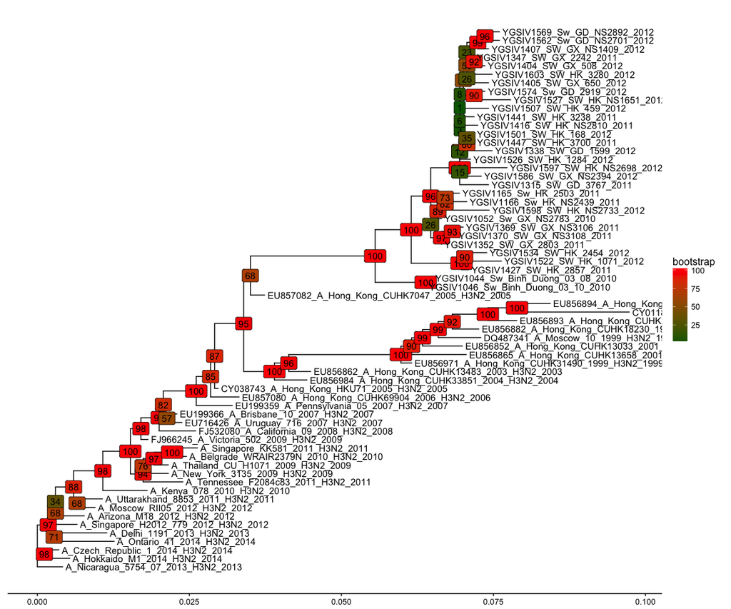

```r
raxml_file <- system.file("extdata/RAxML", "RAxML_bipartitionsBranchLabels.H3", package="ggtree")
raxml <- read.raxml(raxml_file)
ggtree(raxml) + geom_label(aes(label=bootstrap, fill=bootstrap)) + geom_tiplab() +
    scale_fill_continuous(low='darkgreen', high='red') + theme_tree2(legend.position='right')
```

## 4.6 Parsing NHX tree

NHX (New Hampshire eXtended) format is commonly used in phylogenetics software (e.g. [PHYLDOG](http://pbil.univ-lyon1.fr/software/phyldog/)<sup>6</sup>, [RevBayes](http://revbayes.github.io/intro.html)<sup>9</sup>, *etc*.)

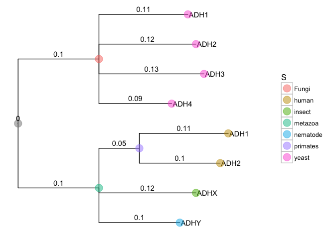

```r
nhxfile <- system.file("extdata", "ADH.nhx", package="ggtree")
nhx <- read.nhx(nhxfile)
ggtree(nhx) + geom_tiplab() + geom_point(aes(color=S), size=5, alpha=.5) +
    theme(legend.position="right") +
    geom_text(aes(label=branch.length, x=branch), vjust=-.5) +
    xlim(NA, 0.3)
```

## 4.7 Parsing EPA and pplacer output

[EPA](http://sco.h-its.org/exelixis/web/software/epa/index.html)<sup>3</sup> and [PPLACER](http://matsen.fhcrc.org/pplacer/)<sup>4</sup> have common output file format, `jplace`.

```r
jpf <- system.file("extdata/sample.jplace",  package="ggtree")
jp <- read.jplace(jpf)
print(jp)
```

```
## 'jplace' S4 object that stored information of
##   '/private/var/folders/32/47tc79h16kjbv_bdb8tncjnh0000gn/T/RtmpBrT5pz/Rinst3ed3105f72df/ggtree/extdata/sample.jplace'.
##
## ...@ tree:
## Phylogenetic tree with 13 tips and 12 internal nodes.
##
## Tip labels:
##  A, B, C, D, E, F, ...
##
## Rooted; includes branch lengths.
##
## with the following features availables:
##   'edge_num',    'likelihood',   'like_weight_ratio',    'distal_length',    'pendant_length'.
```

In *ggtree*, we provide *`get.placements`* method to access the placement.

```r
## get only best hit
get.placements(jp, by="best")
```

[output not shown]

```r
## get all placement
get.placements(jp, by="all")
```

```
##   name edge_num likelihood like_weight_ratio distal_length pendant_length
## 1   AA       24  -61371.30          0.333344      0.000003       0.003887
## 2   BB        1  -61312.21          0.333335      0.000001       0.000003
## 3   BB        2  -61312.21          0.333322      0.000003       0.000003
## 4   BB      550  -61312.21          0.333322      0.000961       0.000003
## 5   CC        8  -61312.23          0.200011      0.000001       0.000003
## 6   CC        9  -61312.23          0.200000      0.000003       0.000003
## 7   CC       10  -61312.23          0.199992      0.000003       0.000003
```

This is only a tiny sample file. In reality, [EPA](http://sco.h-its.org/exelixis/web/software/epa/index.html) and [PPLACER](http://matsen.fhcrc.org/pplacer/) may place thousands of short reads on a reference tree.

# 5 merging tree objects

In ggtree, tree objects can be merged and evidences inferred from different phylogenetic analyses can be combined or compared and visualized.

User can use the command like:

```r
tree <- merge_tree(tree_object_1, tree_object_2)
## it's chainable, and serveral tree objects can be merged into one tree object
tree <- merge_tree(tree_object_1, tree_object_2) %>% merge_tree(tree_object_3) %>% merge_tree(tree_object_4)
```

Here we use a tree analyzed by BEAST and CodeML and merge them into one.

```r
beast_file <- system.file("examples/MCC_FluA_H3.tree", package="ggtree")
beast_tree <- read.beast(beast_file)

rst_file <- system.file("examples/rst", package="ggtree")
mlc_file <- system.file("examples/mlc", package="ggtree")
codeml_tree <- read.codeml(rst_file, mlc_file)

merged_tree <- merge_tree(beast_tree, codeml_tree)

merged_tree
```

```
## 'beast' S4 object that stored information of
##   '/private/var/folders/32/47tc79h16kjbv_bdb8tncjnh0000gn/T/RtmpBrT5pz/Rinst3ed3105f72df/ggtree/examples/MCC_FluA_H3.tree'.
##
## ...@ tree:
## Phylogenetic tree with 76 tips and 75 internal nodes.
##
## Tip labels:
##  A/Hokkaido/30-1-a/2013, A/New_York/334/2004, A/New_York/463/2005, A/New_York/452/1999, A/New_York/238/2005, A/New_York/523/1998, ...
##
## Rooted; includes branch lengths.
##
## with the following features available:
##   'height',  'height_0.95_HPD',  'height_median',    'height_range', 'length',
##   'length_0.95_HPD', 'length_median',    'length_range', 'posterior',    'rate',
##   'rate_0.95_HPD',   'rate_median',  'rate_range',   't',    'N',
##   'S',   'dN_vs_dS', 'dN',   'dS',   'N_x_dN',
##   'S_x_dS',  'marginal_subs',    'joint_subs',   'marginal_AA_subs', 'joint_AA_subs',
## .
```

```r
head(fortify(merged_tree))
```

```
##     node parent branch.length         x  y                  label isTip
## 1      1    115     1.7132967 21.273403 42 A/Hokkaido/30-1-a/2013  TRUE
## 64     2     94     0.4987642 12.273403 19    A/New_York/334/2004  TRUE
## 75     3    149     1.1007898 13.273403 20    A/New_York/463/2005  TRUE
## 86     4     81     1.4515245  7.273403  5    A/New_York/452/1999  TRUE
## 97     5    150     0.7584041 13.273403 22    A/New_York/238/2005  TRUE
## 108    6     80     0.9862567  6.273403  4    A/New_York/523/1998  TRUE
##        branch       angle height      height_0.95_HPD height_median
## 1   20.416754 -111.315789      0                 <NA>            NA
## 64  12.024021    2.368421      9 [8.99999999999999,9]             9
## 75  12.723008    0.000000      8 [7.99999999999999,8]             8
## 86   6.547640   68.684211     14              [14,14]            14
## 97  12.894201  -11.842105      8 [7.99999999999999,8]             8
## 108  5.780274   73.421053     15              [15,15]            15
##                            height_range    length
```

[output cut: 62 more lines]

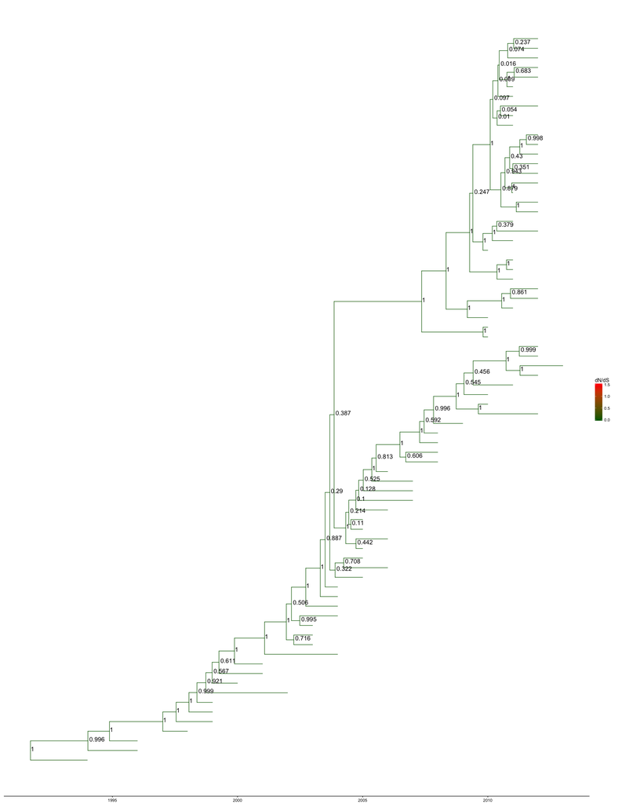

```r
ggtree(merged_tree, aes(color=dN), mrsd="2013-01-01", ndigits = 3) +
    geom_text(aes(label=posterior), vjust=.1, hjust=-.1, size=5, color="black") +
    scale_color_continuous(name='dN/dS', limits=c(0, 1.5),
                           oob=scales::squish, low="darkgreen", high="red")+
    theme_tree2(legend.position="right")
```

# 6 `jplace` file format

The *`jplace`* file format was defined by Masten<sup>12</sup> for phylogenetic placements. We employed this file format to store phylogenetic tree and user specific annotation data. Suppose we have a tree, and the associated data as shown below:

```r
tree <- system.file("extdata", "pa.nwk", package="ggtree")
data <- read.csv(system.file("extdata", "pa_subs.csv", package="ggtree"), stringsAsFactor=FALSE)
print(tree)
```

```
## [1] "/private/var/folders/32/47tc79h16kjbv_bdb8tncjnh0000gn/T/RtmpBrT5pz/Rinst3ed3105f72df/ggtree/extdata/pa.nwk"
```

```r
head(data)
```

```
##   label                          subs    gc
## 1     A                   R262K/K603R 0.444
## 2     B                         R262K 0.442
## 3     C                   N272S/I354T 0.439
## 4     D K104R/F105L/E382D/F480S/I596T 0.449
## 5     E             T208S/V379I/K609R 0.443
## 6     F                   S277P/L549I 0.444
```

The *`data`* contains amino acid substitutions from parent node to child node and GC contents of each node. We can annotate the tree as demonstrated in User specific annotation session of Tree Annotation vignette.

*ggtree* provides a function, *`write.jplace`*, to combine a tree and an associated data and store them to a single *`jplace`* file.

```r
outfile <- tempfile()
write.jplace(tree, data, outfile)
```

Then *`read.jplace`* function was designed to read the *`jplace`* file and store the information to a *`jplace`* object.

```r
jp <- read.jplace(outfile)
print(jp)
```

```
## 'jplace' S4 object that stored information of
##   '/var/folders/32/47tc79h16kjbv_bdb8tncjnh0000gn/T//RtmpsFDb6G/file3efd2bfeb8fc'.
##
## ...@ tree:
## Phylogenetic tree with 15 tips and 13 internal nodes.
##
## Tip labels:
##  K, N, D, L, J, G, ...
##
## Unrooted; includes branch lengths.
##
## with the following features availables:
##   'label',   'subs', 'gc'.
```

Now we know the *`jp`* object stored the tree and the associated amino acid substitution and GC content information, we can view the tree and display the associated annotation data on it directly by *`ggtree`*.

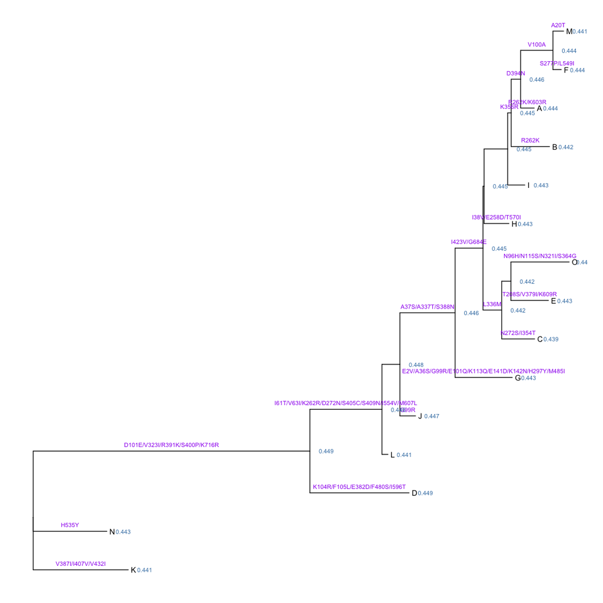

```r
ggtree(jp) +
    geom_text(aes(x=branch, label=subs), color="purple", vjust=-1, size=3) +
    geom_text(aes(label=gc), color="steelblue", hjust=-.6, size=3) +
    geom_tiplab()
```

# References

1. Yang, Z. PAML 4: Phylogenetic analysis by maximum likelihood. *Molecular Biology and Evolution* **24,** 1586–1591 (2007).

2. Bouckaert, R. *et al.* BEAST 2: A software platform for bayesian evolutionary analysis. *PLoS Comput Biol* **10,** e1003537 (2014).

3. Berger, S. A., Krompass, D. & Stamatakis, A. Performance, accuracy, and web server for evolutionary placement of short sequence reads under maximum likelihood. *Systematic Biology* **60,** 291–302 (2011).

4. Matsen, F. A., Kodner, R. B. & Armbrust, E. V. Pplacer: Linear time maximum-likelihood and bayesian phylogenetic placement of sequences onto a fixed reference tree. *BMC Bioinformatics* **11,** 538 (2010).

5. Pond, S. L. K., Frost, S. D. W. & Muse, S. V. HyPhy: Hypothesis testing using phylogenies. *Bioinformatics* **21,** 676–679 (2005).

6. Boussau, B. *et al.* Genome-scale coestimation of species and gene trees. *Genome Res.* **23,** 323–330 (2013).

7. Marazzi, B. *et al.* Locating evolutionary precursors on a phylogenetic tree. *Evolution* **66,** 3918–3930 (2012).

8. Stamatakis, A. RAxML version 8: A tool for phylogenetic analysis and post-analysis of large phylogenies. *Bioinformatics* btu033 (2014). doi:10.1093/bioinformatics/btu033

9. Höhna, S. *et al.* Probabilistic graphical model representation in phylogenetics. *Syst Biol* **63,** 753–771 (2014).

10. Paradis, E., Claude, J. & Strimmer, K. APE: Analyses of phylogenetics and evolution in r language. *Bioinformatics* **20,** 289–290 (2004).

11. Schliep, K. P. Phangorn: Phylogenetic analysis in r. *Bioinformatics* **27,** 592–593 (2011).

12. Matsen, F. A., Hoffman, N. G., Gallagher, A. & Stamatakis, A. A format for phylogenetic placements. *PLoS ONE* **7,** e31009 (2012).